# Practical ML Assignment

Noble Prince

10/19/2020

## The Project:

This project is to apply practical ML learnt from the course on the data set provided from the site http://web.archive.org/web/20161224072740/http:/groupware.les.inf.puc-rio.br/har.

For more info on analysis and data used for training and testing, refer ‘readme.md’ file

## Getting to know the data

I will load and see what the data contains

```r
#loading the training data to train the model
train_link <- "https://d396qusza40orc.cloudfront.net/predmachlearn/pml-training.csv"

train_df <- read.csv(url(train_link))

dim(train_df)
```

```
## [1] 19622   160
```

First up the training data as we need to train the model before testing it.

So it has about 20,000 records and 160 columns.

```r
colnames(train_df)
```

```
##   [1] "X"                        "user_name"
##   [3] "raw_timestamp_part_1"     "raw_timestamp_part_2"
##   [5] "cvtd_timestamp"           "new_window"
##   [7] "num_window"               "roll_belt"
##   [9] "pitch_belt"               "yaw_belt"
##  [11] "total_accel_belt"         "kurtosis_roll_belt"
##  [13] "kurtosis_picth_belt"      "kurtosis_yaw_belt"
##  [15] "skewness_roll_belt"       "skewness_roll_belt.1"
##  [17] "skewness_yaw_belt"        "max_roll_belt"
##  [19] "max_picth_belt"           "max_yaw_belt"
##  [21] "min_roll_belt"            "min_pitch_belt"
##  [23] "min_yaw_belt"             "amplitude_roll_belt"
##  [25] "amplitude_pitch_belt"     "amplitude_yaw_belt"
##  [27] "var_total_accel_belt"     "avg_roll_belt"
##  [29] "stddev_roll_belt"         "var_roll_belt"
```

[output cut: 65 more lines]

```r
str(train_df)
```

```
## 'data.frame':    19622 obs. of  160 variables:
##  $ X                       : int  1 2 3 4 5 6 7 8 9 10 ...
##  $ user_name               : Factor w/ 6 levels "adelmo","carlitos",..: 2 2 2 2 2 2 2 2 2 2 ...
##  $ raw_timestamp_part_1    : int  1323084231 1323084231 1323084231 1323084232 1323084232 1323084232 1323084232 1323084232 1323084232 1323084232 ...
##  $ raw_timestamp_part_2    : int  788290 808298 820366 120339 196328 304277 368296 440390 484323 484434 ...
##  $ cvtd_timestamp          : Factor w/ 20 levels "02/12/2011 13:32",..: 9 9 9 9 9 9 9 9 9 9 ...
##  $ new_window              : Factor w/ 2 levels "no","yes": 1 1 1 1 1 1 1 1 1 1 ...
##  $ num_window              : int  11 11 11 12 12 12 12 12 12 12 ...
##  $ roll_belt               : num  1.41 1.41 1.42 1.48 1.48 1.45 1.42 1.42 1.43 1.45 ...
##  $ pitch_belt              : num  8.07 8.07 8.07 8.05 8.07 8.06 8.09 8.13 8.16 8.17 ...
##  $ yaw_belt                : num  -94.4 -94.4 -94.4 -94.4 -94.4 -94.4 -94.4 -94.4 -94.4 -94.4 ...
##  $ total_accel_belt        : int  3 3 3 3 3 3 3 3 3 3 ...
##  $ kurtosis_roll_belt      : Factor w/ 397 levels "","-0.016850",..: 1 1 1 1 1 1 1 1 1 1 ...
##  $ kurtosis_picth_belt     : Factor w/ 317 levels "","-0.021887",..: 1 1 1 1 1 1 1 1 1 1 ...
##  $ kurtosis_yaw_belt       : Factor w/ 2 levels "","#DIV/0!": 1 1 1 1 1 1 1 1 1 1 ...
```

[output cut: 86 more lines]

We see that there is a column called Classe which is referred to be used to predict with.

```r
unique(train_df$classe)
```

```
## [1] A B C D E
## Levels: A B C D E
```

```r
table(train_df$classe)/nrow(train_df)
```

```
##
##         A         B         C         D         E
## 0.2843747 0.1935073 0.1743961 0.1638977 0.1838243
```

I will now correct the data to make the process easier

```r
# loading the required caret library
library(caret)
na_val <- sapply(train_df, function(x) mean(is.na(x))) > 0.95
train_df <- train_df[, na_val == FALSE]
xy <- nearZeroVar(train_df)
trainDF <- train_df[,-xy]
dim(trainDF)
```

```
## [1] 19622    59
```

## Analysis

For Cross Validation:

```r
# removing non numeric columns
trainDF <- trainDF[, -(1:7)]
dim(trainDF)
```

```
## [1] 19622    52
```

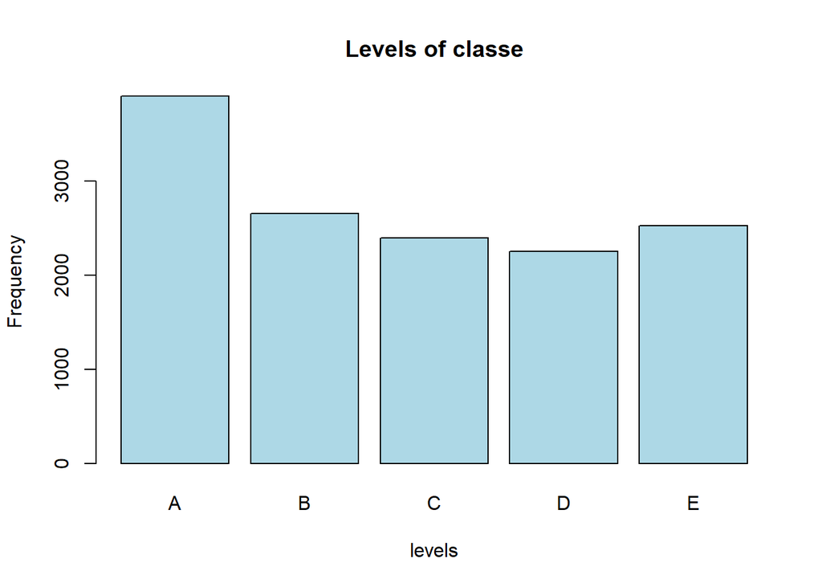

```r
Partition <- createDataPartition(trainDF$classe, p = 0.7, list = FALSE)

training1 <- trainDF[Partition,]
testing1 <- trainDF[-Partition,]

plot(training1$classe, col="light blue", main="Levels of classe", xlab="levels", ylab="Frequency")
```

```r
# we already know the amount of frequency in % each classe has for the whole data set but this is to check for the partitioned one.
```

#### RandomForest and DecisionTree

```r
dim(training1)
```

```
## [1] 13737    52
```

```r
library(rpart)
library(rpart.plot)
library(randomForest)
library(rattle)
```

Now we make a Decision Tree to see its accuracy with our cross validation model

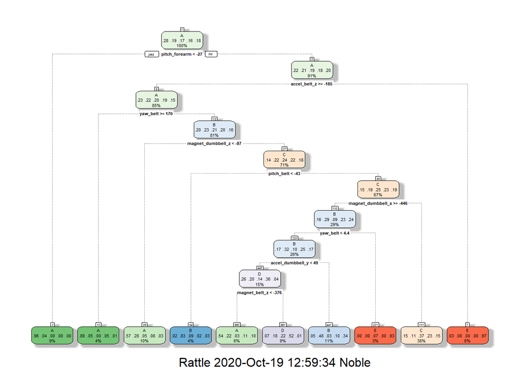

```r
# creating a plot of the decision tree to understand how its working
modelDT <- train(classe ~. , data = training1, method = "rpart");fancyRpartPlot(modelDT$finalModel)
```

```r
#the plot would give us idea on how its making decisions
```

Further we validate our results using confusion matrix

```r
predictionDT <- predict(modelDT, testing1)

confusionMatrix(predictionDT, testing1$classe)
```

```
## Confusion Matrix and Statistics
##
##           Reference
## Prediction    A    B    C    D    E
##          A 1278  295   46   89   57
##          B   44  518   42   69  219
##          C  315  223  808  493  350
##          D   25  103  122  313    3
##          E   12    0    8    0  453
##
## Overall Statistics
##
##                Accuracy : 0.5726
##                  95% CI : (0.5599, 0.5853)
##     No Information Rate : 0.2845
##     P-Value [Acc > NIR] : < 2.2e-16
##
##                   Kappa : 0.459
##
##  Mcnemar's Test P-Value : < 2.2e-16
##
## Statistics by Class:
##
##                      Class: A Class: B Class: C Class: D Class: E
## Sensitivity            0.7634  0.45478   0.7875  0.32469  0.41867
## Specificity            0.8844  0.92120   0.7158  0.94859  0.99584
## Pos Pred Value         0.7241  0.58072   0.3691  0.55300  0.95772
## Neg Pred Value         0.9039  0.87563   0.9410  0.87761  0.88378
## Prevalence             0.2845  0.19354   0.1743  0.16381  0.18386
## Detection Rate         0.2172  0.08802   0.1373  0.05319  0.07698
## Detection Prevalence   0.2999  0.15157   0.3720  0.09618  0.08037
## Balanced Accuracy      0.8239  0.68799   0.7517  0.63664  0.70725
```

```r
# setting the seed and fitting the model
set.seed(121212)
# no of trees to 50 to minimize the modelfit time and increasing efficiency
modelRF <- train(classe ~., data = training1, method = "rf", ntree = 50)
```

checking the accuracy

```r
predictRF <- predict(modelRF, testing1)

confusionMatrix(predictRF, testing1$classe)
```

```
## Confusion Matrix and Statistics
##
##           Reference
## Prediction    A    B    C    D    E
##          A 1674    5    0    0    0
##          B    0 1130    5    1    0
##          C    0    3 1019   15    2
##          D    0    1    2  948    0
##          E    0    0    0    0 1080
##
## Overall Statistics
##
##                Accuracy : 0.9942
##                  95% CI : (0.9919, 0.996)
##     No Information Rate : 0.2845
##     P-Value [Acc > NIR] : < 2.2e-16
##
##                   Kappa : 0.9927
##
##  Mcnemar's Test P-Value : NA
##
## Statistics by Class:
##
##                      Class: A Class: B Class: C Class: D Class: E
## Sensitivity            1.0000   0.9921   0.9932   0.9834   0.9982
## Specificity            0.9988   0.9987   0.9959   0.9994   1.0000
## Pos Pred Value         0.9970   0.9947   0.9808   0.9968   1.0000
## Neg Pred Value         1.0000   0.9981   0.9986   0.9968   0.9996
## Prevalence             0.2845   0.1935   0.1743   0.1638   0.1839
## Detection Rate         0.2845   0.1920   0.1732   0.1611   0.1835
## Detection Prevalence   0.2853   0.1930   0.1766   0.1616   0.1835
## Balanced Accuracy      0.9994   0.9954   0.9945   0.9914   0.9991
```

As expected RF model gives better accuracy than DT model in case of cross validation itself.

## Loading test data and testing it

```r
test_link <- "https://d396qusza40orc.cloudfront.net/predmachlearn/pml-testing.csv"

test_df <- read.csv(url(test_link))

dim(test_df)
```

```
## [1]  20 160
```

```r
predict(modelRF, test_df)
```

```
##  [1] B A B A A E D B A A B C B A E E A B B B
## Levels: A B C D E
```

##### Hence the analysis done clearly shows the confidence interval for random forest method is almost 100 and for a decision tree its near about 50. Similarly comparing other attrbutes also pointed it out that RF is better and reliable than DT though time taking to train the model.

##### So we can rely on the results we get from this model as we have got above for 20 records.